# Seminar Tema 3

Minstelønn og fagforeninger

Published

October 3, 2024

## Oppgave 1 - Minstelønn

Anta at etterspørselen på arbeid er gitt ved:

$$L^D = \frac{E}{\alpha} - \frac{1}{\alpha} w$$

og at tilbudet av arbeid gis av:

$$L^S = -\frac{T}{\beta} + \frac{1}{\beta} \cdot w,$$

der $E = 250$, $\alpha = 0.5$, $T = 10$, og $\beta = 0.5$

### Anta først at markedet er karakterisert av fullkommen konkurranse. Utled lønn og sysselsetting på dette markedet matematisk. Illustrer grafisk.

#### Matematisk utledning

**Steg 1: Sett inn verdiene i funksjonene**

Etterspørsel:
$$L^D = \frac{250}{0.5} - \frac{1}{0.5} w = 500 - 2w$$

Tilbud:
$$L^S = -\frac{10}{0.5} + \frac{1}{0.5} w = -20 + 2w$$

**Steg 2: Finn likevekten ved å sette** $L^D = L^S$

$$500 - 2w = -20 + 2w$$

**Steg 3: Løs ligningen for** $w$

Legg til $2w$ på begge sider:
$$500 = -20 + 4w$$

Legg til 20 på begge sider:
$$520 = 4w$$

Del begge sider på 4:
$$w^{FK} = 130$$

**Steg 4: Finn likevektsmengden av arbeid** $L$

Sett $w^{FK}$ i etterspørselsfunksjonen:
$$L^{FK} = 500 - 2w = 500 - 2 \times 130 = 240$$

#### Konklusjon

- **Likevektslønn:** $w^{FK} = 130$ NOK
- **Likevektssysselsetting:** $L^{FK} = 240$ arbeidere

### Grafisk illustrasjon

For å kunne tegne figuren er det lettere å bruke de inverse etterspørsels- og tilbudsfunksjonene:

- den inverse etterspørselskurven: $L^D = 500 - 2w \iff w = 250 - 0.5L$
- den inverse tilbudskurven: $L^S = -20 + 2w \iff w = 10 + 0.5L$

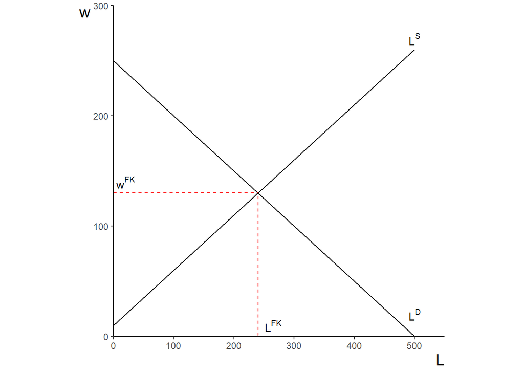

```r
rm(list = ls())

suppressPackageStartupMessages(library(tidyverse))


l_1 <- seq(0, 550, by = 1) # 550 gir maks-verdi på x- og y-aksen


df <- data.frame(l_1)

#lag aksen for tegningen

axes_1 <- ggplot(df, aes(l_1))+
  labs(x="L", y="w") +
  theme(axis.title = element_text(size = 15),
        plot.title = element_text(size = 15),
        panel.background = element_blank(), # hvit bakgrunn
        axis.line = element_line(colour = "black"), # sett inn akselinjer
        axis.title.x = element_text(hjust = 1),
        axis.title.y = element_text(angle = 0, vjust = 1, hjust=1))+ # juster labels på aksene
  coord_fixed(ratio = 1)+ # lik skala for x og y aksen
  scale_x_continuous(limits = c(0, 550), expand = c(0, 0))+
  scale_y_continuous(limits = c(0, 300), expand = c(0, 0))+ # begrense aksene og sikre at akselinjene møttes i (0,0).
  coord_fixed(ratio = (550 - 0) / (300 - 0)) # Juster skalaen på x- og y-aksel slik at figuren blir symmetrisk


# Etterspørsel etter og tilbud av arbeid

Demand <- function(l_1) {
  return(250 - 0.5*l_1)   # Etterspørselsfunksjonen w = 250 - 0.5*l_1
}

Supply <- function(l_1) {
  return(10 + 0.5 * l_1)  # Tilbudsfunksjonen w = 10 + 0.5 * l_1
}

figur_1 <- axes_1 +
  geom_segment(aes(x = 0, y = Demand(0), xend = 500, yend = Demand(500))) + # Etterspørselskurven. Beregn skjæringspunkt med x-akse og sett inn for "X"
    annotate("text", x = 500, y = 20, label = expression(L^D)) + # Velg hvor du vil sette 'label' til etterspørselen (bytt ut X og Y)
  geom_segment(aes(x = 0, y = Supply(0), xend = 500, yend = Supply(500))) + #Tilbudskurven: bruk samme X som du brukte til Demand (X)
    annotate("text", x = 500, y = 270, label = expression(L^S))+  # Velg hvor du vil sette 'label' til tilbudet (bytt ut X og Y)
  geom_segment(aes(x=240, y=0, xend=240, yend=130), linetype="dashed", color="red")+ #Likevekt: vertikal linje. Bytt ut X til nivået på L* og Y til verdien på w*
   annotate("text",x=265,y=10, label=expression(L^FK))+ # Label til L* (bytt ut X og Y)
  geom_segment(aes(x=0, y=130, xend=240, yend=130), linetype="dashed", color="red")+ #Likevekt: horisontal linje. Bytt ut X til nivået på L* og Y til nivået på w*
   annotate("text",x=20,y=140, label=expression(w^FK)) #Label til w* (bytt ut X og Y)
figur_1
```

## Tenk deg nå at regjeringa innfører en minstelønn på 150 NOK. Hva skjer med lønn og sysselsetting på markedet?

**Innføring av minstelønn på 150 NOK**

**Steg 1: Beregn ny etterspurt og tilbudt mengde arbeid ved** $w = 150$

Etterspørsel:
$$L^D = 500 - 2 \times 150 = 200$$

Tilbud:
$$L^S = -20 + 2 \times 150 = 280$$

**Steg 2: Analyser effekten**

- **Etterspurt mengde arbeid:** 200 arbeidere
- **Tilbudt mengde arbeid:** 280 arbeidere
- **Sysselsettingen blir begrenset av etterspørselen:** 200 arbeidere
- **Arbeidsledighet:** $280 - 200 = 80$ arbeidere

#### Konklusjon

- **Lønn stiger til fra 130 NOK til minstelønnen på 150 NOK**
- **Sysselsetting reduseres fra 240 til 200 arbeidere**

**Grafisk illustrasjon:**

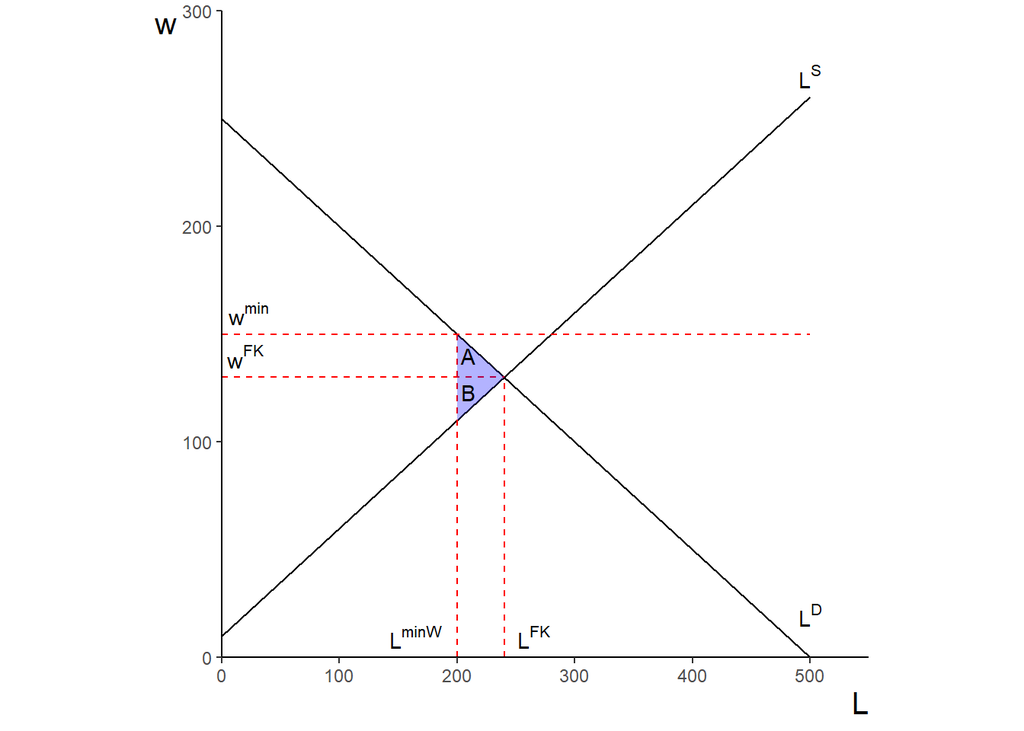

```r
figur_2 <- axes_1 +
  geom_segment(aes(x = 0, y = Demand(0), xend = 500, yend = Demand(500))) + # Etterspørselskurven. Beregn skjæringspunkt med x-akse og sett inn for "X"
    annotate("text", x = 500, y = 20, label = expression(L^D)) + # Velg hvor du vil sette 'label' til etterspørselen (bytt ut X og Y)
  geom_segment(aes(x = 0, y = Supply(0), xend = 500, yend = Supply(500))) + #Tilbudskurven: bruk samme X som du brukte til Demand (X)
    annotate("text", x = 500, y = 270, label = expression(L^S))+  # Velg hvor du vil sette 'label' til tilbudet (bytt ut X og Y)
  geom_segment(aes(x=240, y=0, xend=240, yend=130), linetype="dashed", color="red")+ #Likevekt: vertikal linje. Bytt ut X til nivået på L* og Y til verdien på w*
   annotate("text",x=265,y=10, label=expression(L^FK))+ # Label til L* (bytt ut X og Y)
  geom_segment(aes(x=0, y=130, xend=240, yend=130), linetype="dashed", color="red")+ #Likevekt: horisontal linje. Bytt ut X til nivået på L* og Y til nivået på w*
   annotate("text",x=20,y=140, label=expression(w^FK))+ #Label til w* (bytt ut X og Y)
   annotate("text",x=23,y=160, label=expression(w^min))+  #Label til minstelønn (bytt ut X og Y)
  geom_segment(aes(x=0, y=150, xend=500, yend=150), linetype="dashed", color="red")+  # likevekt: minstelønn - horisontal linje
  geom_segment(aes(x=200, y=0, xend=200, yend=150), linetype="dashed", color="red")+  # likevekt: minstelønn - vertikal linje
   annotate("text",x=165,y=10, label=expression(L^minW)) + #Label til L ved minstelønn
      geom_polygon(data = data.frame(x = c(200, 240, 200), y = c(150, 130, 110)), # Dødvekstap. Bytt ut X1, X2,X3 mot verdier på x-akselen. Bytt ut Y1, Y2 og Y3 mot verdier langs Y-akselen
               aes(x = x, y = y), # Denne koden skal du ikke endre.
               fill = "blue", alpha = 0.3)+
  annotate("text",x=210,y=140, label="A") + # Labels til dødvekstap. Bytt ut X og Y.
  annotate("text",x=210,y=123, label="B") # Labels til dødvekstap. Bytt ut X og Y.

figur_2
```

### Anta nå at det kun er én arbeidsgiver på markedet som etterspør arbeid. Bedriften er pristaker på godemarkedet. Utled matematisk og illustrer grafisk hva sysselsetting og lønn ville ha vært i likevekt **uten minstelønn** i denne situasjonen.

I et monopsonistisk arbeidsmarked er det kun én arbeidsgiver som bestemmer lønn og sysselsetting.Lønnen $w$ er avhengig av hvor mange arbeidere bedriften ansetter, fordi bedriften har markedsmakt til å påvirke lønnsnivået. Monopsonisten møter hele tilbudet av arbeidskraft (= ulike reservasjonslønner). For å ansette flere, må monopsonisten da akseptere å betale høyere lønn.

$$\Pi = p \cdot f(L) - w(L) \cdot L$$

**Steg 1: Utled arbeidstilbudskurven i form av lønn som funksjon av sysselsetting**

Profitten maksimeres når

$$\frac{∂Π}{∂L} = 0$$
$$p \cdot \frac{∂ f(L)}{∂ L} - \frac{∂ w(L)}{∂ L} \cdot L - w(L) = 0$$
$$p \cdot \frac{∂ f(L)}{∂ L} = \frac{∂ w(L)}{∂ L} \cdot L + w(L)$$
$$MRP_L= \frac{∂ w(L)}{∂ L} \cdot L + w(L)=MLC.$$
Husk at $MRP_L$ er etterpørselskurven etter arbeid.

**Steg 2: Finne uttrykket for monopsonistens grensekostnader ($MLC$)**

Vi får vite $w(L)$ fra tilbudsfunksjonen:
$$L^S(w) = -20 + 2w \implies w(L) = 0.5L + 10$$

Vi regner ut monopsonistens grenskostnader:
$$MLC = \frac{∂ w(L)}{∂ L} \cdot L + w(L) = 0.5L + 0.5L + 10 = L + 10$$
**Steg 3: Vi finner likevektspunktet ved å sett $MLC$ lik etterspørselsfunksjonen ($MRP_L$)**

Etterspørselsfunksjonen ($MRP_L$):
$$L^D = 500 - 2w \implies w = 250 - 0.5L$$

MRP_L:
$$MRP_L = 250 - 0.5L$$

Sett $MLC = MRP_L$:
$$L + 10 = 250 - 0.5L$$

**Steg 4: Løs ligningen for** $L$

Legg til $0.5L$ på begge sider:
$$1.5L = 240 \implies L^M = 160$$

**Steg 5: Finn monopsonistens lønn** $w$

Bruk arbeidstilbudskurven ved L^M = 160:
$$w^M = 0.5 \times 160 + 10 = 90$$

#### Konklusjon:

- **Monopsonistens lønn:** $w = 90$ NOK
- **Monopsonistens sysselsetting:** $L = 160$ arbeidere

### Grafisk illustrasjon:

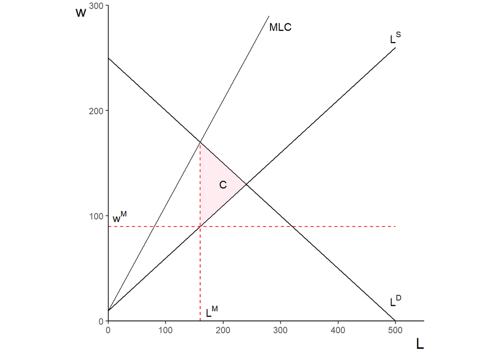

```r
MLC <- function(l_1) {
  return(10 + l_1) #Sett in ligning som beskriver marginalkostnaden for arbeid som en funksjon av mengden arbeid
}


figur_3 <- axes_1 +
  geom_segment(aes(x = 0, y = Demand(0), xend = 500, yend = Demand(500))) + # Etterspørselskurven. Beregne skjærningspunkt med x-aksel og sett inn for "X"
    annotate("text", x = 500, y = 20, label = expression(L^D)) + #Label til LD. bytt ut X og Y
  geom_segment(aes(x = 0, y = Supply(0), xend = 500, yend = Supply(500))) + #Tilbudskurven: bruk samme X som du brukte til Demand (X)
    annotate("text", x = 500, y = 270, label = expression(L^S))+ #Label til LS
  geom_segment(aes(x = 0, y = MLC(0), xend = 280, yend = MLC(280))) + #MLC-kurven. Her er det lurt å regne hva y-blir slik at du ikke tegner utenom graf-rommet. Her har jeg brukt 280
    annotate("text", x = 300, y = 280, label = "MLC")+ #Label til MLC. Bytt ut X og Y
  geom_segment(aes(x=160, y=0, xend=160, yend=170), linetype="dashed", color="red")+ # Likevekt monopson: Vertikal linje (L^M). Bytt ut X og Y
   annotate("text",x=180,y=10, label=expression(L^M))+ #Label til sysselsetting ved monopson. Bytt ut X og Y
  geom_segment(aes(x=0, y=90, xend=500, yend=90), linetype="dashed", color="red")+# Likevekt monopson: Horisontal linje (w^M). Bytt ut X og Y
   annotate("text",x=20,y=100, label=expression(w^M))+ #Label til lønn ved monopson. Bytt ut X og Y
        geom_polygon(data = data.frame(x = c(160, 240, 160), y = c(170, 130, 90)), # Dødvekstap. Bytt ut X1, X2,X3 mot verdier på x-akselen. Bytt ut Y1, Y2 og Y3 mot verdier langs Y-akselen
               aes(x = x, y = y), # Denne koden skal du ikke endre.
               fill = "pink", alpha = 0.3)+
   annotate("text",x=200,y=130, label="C") # Label til dødvekstap. Bytt ut X og Y.

figur_3
```

### Illustrer grafisk effekten av å introdusere en minstelønn på 150 NOK i dette tilfellet (du trenger ikke å utlede dette matematisk da dette krever bruk av Kuhn-Tucker-vilkår).

**Steg 1: Finn sysselsetting ved minstelønn** $w^{min} = 150$

Etterspørsel etter arbeidere (= sysselsetting):
$$L^D = 500 - 2 \times 150 = 200$$

Tilbud:
$$L^S = -20 + 2 \times 150 = 280$$

**Steg 2: Analyser effekten**

- **Bedriften må betale minst 150 NOK i lønn.**
- **Bedriften vil ansette opp til der $MRP_L$ = minstelønn:**

##### Konklusjon:

- **Lønn øker fra 90 NOK til 150 NOK.**
- **Sysselsetting øker fra 160 til 200 arbeidere.**

**Grafisk illustrasjon:**

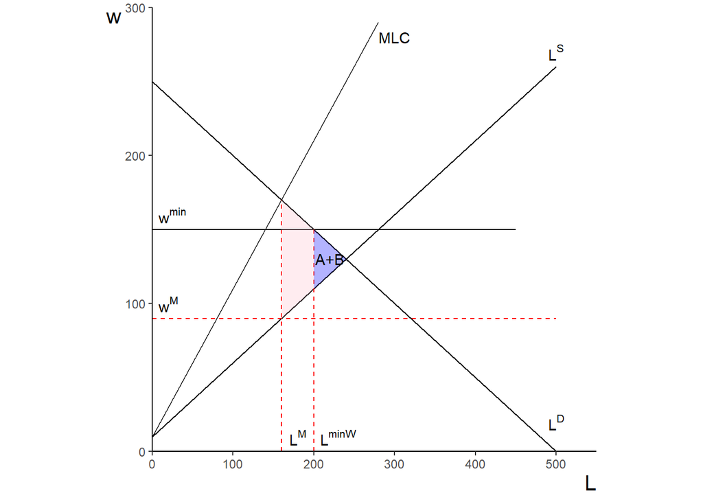

```r
figur_4 <- axes_1 +
  geom_segment(aes(x = 0, y = Demand(0), xend = 500, yend = Demand(500))) + # Etterspørselskurven. Beregne skjærningspunkt med x-aksel og sett inn for "X"
    annotate("text", x = 500, y = 20, label = expression(L^D)) + #Label til LD. bytt ut X og Y
  geom_segment(aes(x = 0, y = Supply(0), xend = 500, yend = Supply(500))) + #Tilbudskurven: bruk samme X som du brukte til Demand (X)
    annotate("text", x = 500, y = 270, label = expression(L^S))+ #Label til LS
  geom_segment(aes(x = 0, y = MLC(0), xend = 280, yend = MLC(280))) + #MLC-kurven. Her er det lurt å regne hva y-blir slik at du ikke tegner utenom graf-rommet. Her har jeg brukt 280
    annotate("text", x = 300, y = 280, label = "MLC")+ #Label til MLC. Bytt ut X og Y
  geom_segment(aes(x=160, y=0, xend=160, yend=170), linetype="dashed", color="red")+ # Likevekt monopson: Vertikal linje (L^M). Bytt ut X og Y
   annotate("text",x=180,y=10, label=expression(L^M))+ #Label til sysselsetting ved monopson. Bytt ut X og Y
  geom_segment(aes(x=0, y=90, xend=500, yend=90), linetype="dashed", color="red")+# Likevekt monopson: Horisontal linje (w^M). Bytt ut X og Y
   annotate("text",x=20,y=100, label=expression(w^M))+ #Label til lønn ved monopson. Bytt ut X og Y

  geom_segment(aes(x=0, y=150, xend=450, yend=150))+ #Likevekt ved minstelønn. Horisontal linje (Wmin). Bytt ut Y
   annotate("text",x=25,y=160, label=expression(w^min))+ #Label til minstelønn. Bytt ut X og Y
  geom_segment(aes(x=200, y=0, xend=200, yend=150), linetype="dashed", color="red")+ #Likevekt ved minstelønn. Vertikal linje (L^wmin). byttut X og Y
   annotate("text",x=230,y=10, label=expression(L^minW)) + #Label til sysselsetting ved minstelønn (L^Wmin). Bytt ut X og Y
        geom_polygon(data = data.frame(x = c(200, 240, 200), y = c(150, 130, 110)), #Dødvekstap ved minstelønn. Bytt ut X og Y
               aes(x = x, y = y), #Ikke endre denne koden
               fill = "blue", alpha = 0.3)+
   annotate("text",x=220,y=130, label="A+B")+ #Labels til dødvekstap ved minstelønn
         geom_polygon(data = data.frame(x = c(160, 200, 200, 160), y = c(90, 110, 150, 170)), # Reduksjon i dødvektstap fra Monopson. Bytt ut X og Y
               aes(x = x, y = y), #Ikke endre denne koden
               fill = "pink", alpha = 0.3)

figur_4
```

**Økonomisk intuisjon:** I et monopsonistisk marked kan en passende satt minstelønn eliminere monopsonistens markedsmakt, øke lønnen og potensielt øke sysselsettingen.

## Oppgave 2 - Fagforeningsmonopol

Anta at markedets etterspørsel på arbeid er gitt ved:

$$L^D(w) = \frac{800}{0.08} - \frac{1}{0.08} \cdot w,$$
der $w$ er reallønn og $L$ er antall sysselsattte. Anta at alle arbeidere er organisert i en fagforening. Fagforeningen sitt mål er å maksimere den summerte nytten blant medlemmene.

Anta at fagforeningen sin nyttefunksjon er gitt ved:

$$U^F = (w - w^r) \cdot L$$

Der $w^r = 100$ er reservasjonslønna som vi antar er lik for alle arbeidere.

Anta at fagforeningen har monopol på arbeidsmarkedet og at det ikke er forhandling. Arbeidsgiverne er pristakere.

- Utled matematisk, illustrer grafisk og gi økonomisk intuisjon til lønna som fagforeningen vil sette dersom den maksimerer nytten til medlemmene sine. Beregn nivå på sysselsetting.

**Steg 1: Uttrykk sysselsetting som funksjon av lønn**

Etterspørsel etter arbeid:
$$L^D(w) = 10,000 - 12.5w$$

**Steg 2: Sett inn** $L^D(w)$ i nyttefunksjonen
$$U^F(w) = (w - 100)(10000 - 12.5w)$$

**Steg 3: Utvid nyttefunksjonen**
$$U^F(w) = (w - 100)(10000 - 12.5w) = 10000w - 12.5w^2 - 1000000 + 1,25w$$

Forenkle:
$$U^F(w) = (11250w - 12.5w^2 - 1000000)$$

**Steg 4: Vi finner maksimum for nyttefunksjonen med hensyn på** $w$ ved å sette den deriverte lik null
$$\frac{∂U^F}{∂w} = 11250 - 2*12.5w = 11,250 - 25w = 0$$

$$\frac{dU^F}{dw} = 11,250 - 25w = 0$$

**Steg 5: Løs for** $w$

$$25w = 11,250 \implies w^M = 450$$

**Steg 6: Finn sysselsettingen** $L$ ved å sette $w^M$ i etterspørselsfunksjonen

$$L = 10,000 - 12.5 \times 450 = 4375$$

**Konklusjon:**

- **Fagforeningens optimale lønn:** $w = 450$ NOK
- **Sysselsetting:** $L = 4375$ arbeidere

**Grafisk illustrasjon:**

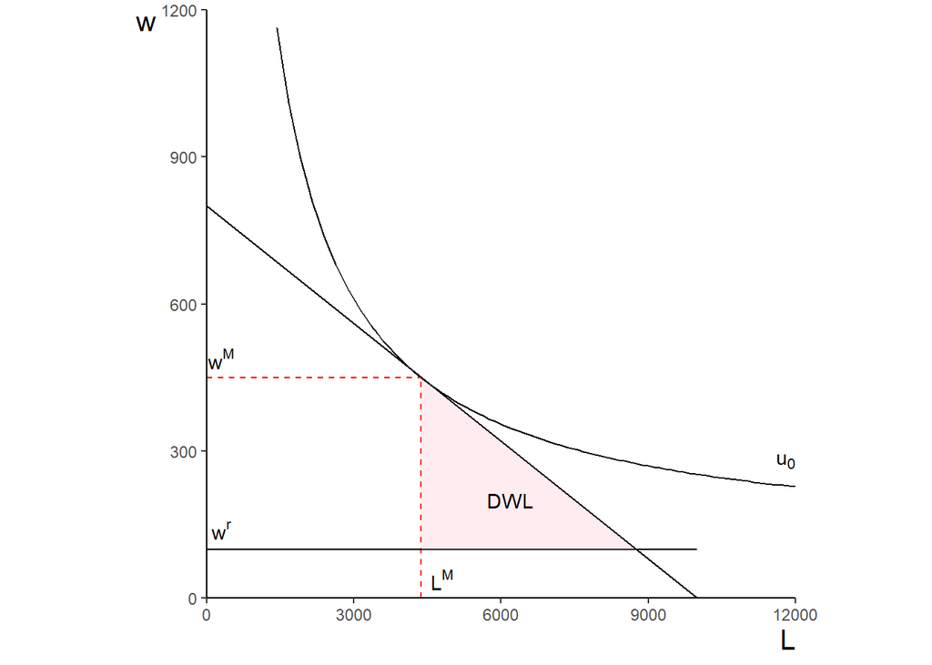

```r
l_2 <- seq(0, 12000, by = 1) # 12000 er satt for å se til at vi har tilstrekkelig lang x-aksel
LD <- function(l_2) {
  return(800-0.08 * l_2) #Sett inn ligning for etterspørselen på arbeid
}


df <- data.frame(l_2)

#lag aksen for tegningen

axes_2 <- ggplot(df, aes(l_2))+
  labs(x="L", y="w") +
  theme(axis.title = element_text(size = 15),
        plot.title = element_text(size = 15),
        panel.background = element_blank(), # hvit bakgrunn
        axis.line = element_line(colour = "black"), # sett inn akselinjer
        axis.title.x = element_text(hjust = 1),
        axis.title.y = element_text(angle = 0, vjust = 1, hjust=1))+ # juster labels på aksene
  coord_fixed(ratio = 1)+ # lik skala for x og y aksen
  scale_x_continuous(limits = c(0, 12000), expand = c(0, 0))+
  scale_y_continuous(limits = c(0, 1200), expand = c(0, 0))+ # begrense aksene og sikre at akselinjene møttes i (0,0).
  coord_fixed(ratio = (12000 - 0) / (1200 - 0)) #Justering for å se til at grafen blir kvadratisk (pen)

# nyttefunkjsonen som brukes U=(w-wr)*L

# vi angir noen indifferenskurver
I_M <- function(l_2) ((1531250/l_2)+100)  #Sett inn nyttenivået som fagforeningen får dersom den maksimerer nytten gitt etterspørselen på arbeid. Sett inn tall for wr

figur_5 <- axes_2 +
  geom_segment(aes(x = 0, y = LD(0), xend = 10000, yend = LD(10000))) + # Etterspørsel: Sett inn tall for X (nivå på L da w = 0)
    annotate("text", x = 20, y = 10000, label = expression(L^D)) + #Label til LD. Sett inn tall for X og Y
    stat_function(df, # Fagforeningens indifferansekurve (NB: Her har vi kun med maks nyttenivå gitt etterspørselen)
        fun=I_M,
        mapping = aes()
        ) +
    annotate("text",x=11800,y=280, label=expression(u[0]))+ #Label til indifferansekurven. Bytt ut X og Y
  geom_segment(aes(x=4375, y=0, xend=4375, yend=450), linetype="dashed", color="red")+ # Likevekt: Vertikal linje (L ved fagforeningsmonopol)
    annotate("text",x=4800,y=40, label=expression(L^M))+ #Label til L^M. Bytt ut X og Y
  geom_segment(aes(x=0, y=450, xend=4375, yend=450), linetype="dashed", color="red")+ #Likevekt: horisontal linje (w ved fagforeningsmonopol)
    annotate("text",x=300,y=490, label=expression(w^M))+ #Label til w^M. Bytt ut X og Y
  geom_segment(aes(x=0, y=100, xend=10000, yend=100))+ # Reservasjonslønn til medlemmene.
    annotate("text",x=300,y=140, label=expression(w^r))+ #Label til w^r
           geom_polygon(data = data.frame(x = c(4375, 8750, 4375), y = c(100, 100,450)), #Dødvekstap
               aes(x = x, y = y), #Ikke endre denne koden
               fill = "pink", alpha = 0.3)+
  annotate("text",x=6200,y=200, label="DWL") #Label til dødvekstap


figur_5
```

**Økonomisk intuisjon:**

Fagforeningen søker å maksimere den samlede nytten til medlemmene, som er produktet av lønnsøkningen over reservasjonslønn og antall sysselsatte. Ved å sette en høyere lønn reduserer de sysselsettingen, men øker lønnen for de som er sysselsatt.